# Майнор "Интеллектуальный анализ данных"

# Курс "Введение в анализ данных"

# Лабораторная работа №2. Кластерный анализ.

# Часть 1

В данном задании вам необходимо **самостоятельно** реализовать один из алгоритмов кластеризации.  
По аналогии с классами в scikit-learn, нужно реализовать класс, наследуемый от [Base Estimator](https://scikit-learn.org/stable/modules/generated/sklearn.base.BaseEstimator.html).  
Подробнее про реализацию своих моделей в scikit-learn: [here](https://scikit-learn.org/stable/developers/develop.html#rolling-your-own-estimator).  
В классе помимо `__init__()` нужно реализовать два метода:

- `fit()` - метод, выполняющий кластеризацию данных.
- `predict()` - метод, определяющий для нового объекта, к какому из кластеров он относится.

Для удобства можно создавать дополнительные методы класса, которые будут вызываться в `fit()` или `predict()`.  
Функции для вычисления расстояний *между объектами* самим реализовывать не нужно, используйте реализации из `scipy`.

```python
from sklearn.base import BaseEstimator, ClusterMixin
from scipy.spatial.distance import euclidean, cityblock, minkowski, chebyshev

class My_Clust(BaseEstimator, ClusterMixin):
    """
    My implementation of clustering algorithm
    """

    def __init__(self, metric, linkage, n_clusters = None):

        self.z_ = []
        self.data = None
        self.labels = None
        self.metric = metric
        self.n_clusters = n_clusters
        self.linkage = linkage
        self.cl = [[]]
        self.data_ = None
        self.methods_dict = {'single': self.single, 'complete':self.complete, 'average': self.average}


    def single(self, a, b):
        min_dist = 10000
        for i in a:
            for j in b:

                dist = self.metric(self.data_[i], self.data_[j])
                if  dist < min_dist:
                    min_dist = dist
        return min_dist


    def complete(self, a, b):
        max_dist = self.metric(self.data_[a[0]], self.data_[b[0]])
        for i in a:
            for j in b:
                dist = self.metric(self.data_[i], self.data_[j])
                if  dist > max_dist:
                    max_dist = dist
        return max_dist


    def average(self, a, b):
        dist = 0
        for i in a:
            for j in b:
                dist+= self.metric(self.data_[i], self.data_[j])
        return dist /(len(a) * len(b))


    def clusters(self):
        self.cl = []
        lab_cl = list(set(self.labels))
        for i in range(len(lab_cl)):
            self.cl.append([])
            for j in range(len(self.labels)):
                if self.labels[j] == lab_cl[i]:
                    self.cl[i].append(j)


    def fit(self, X):
        self.data_ = X
        min_dist = 100000
        self.cl = [ [i] for i in range (len(X))]
        nums_cl = [ i for i in range (len(X))]
        for i in range (0, len(X) - 1):
            min_dist = 10000
            for a_cl in range(len(nums_cl)- 1):
                for b_cl in range(a_cl + 1, len(nums_cl)):
                    dist = self.methods_dict[self.linkage](self.cl[a_cl], self.cl[b_cl]);
                    if  dist < min_dist:
                        min_dist, pos_a, pos_b = dist, a_cl, b_cl

            self.z_.append([nums_cl[pos_a], nums_cl[pos_b], min_dist, len(self.cl[pos_a]) + len(self.cl[pos_b])])
            self.cl.append(self.cl[pos_a] + self.cl[pos_b])
            nums_cl.append(len(X) + i)

            self.cl.pop(pos_a)
            self.cl.pop(pos_b - 1)
            nums_cl.pop(pos_a)
            nums_cl.pop(pos_b - 1)

        self.labels = self.get_labels()
        self.clusters()
        return self.z_


    def predict(self, obj):
        self.data_.append(obj)
        min_dist = 10000
        label = 0
        for i in range(len(self.cl)):
            dist = self.methods_dict[self.linkage]( self.cl[i], [len(self.data_) - 1]);
            if dist < min_dist:
                min_dist, label = dist, self.labels[self.cl[i][0]]
        return label


    def get_labels(self):
        self.labels = [i for i in range(1, len(self.z_) + 3)]
        for i in range(len(self.z_) - self.n_clusters + 2):
            for j in range(len(self.labels)):
                if self.labels[j]  == self.z_[i][1] or self.labels[j]  == self.z_[i][0]:
                    self.labels[j] = len(self.labels) + i + 1
        return self.labels
```

### Вариант №1

Алгоритм агломеративной кластеризации.

Параметры:

- **metric:** Функция расстояния между объектами. Должны поддерживаться метрики из `scipy.spatial.distance`, самописные функции (callable) и предрассчитанная матрица расстояний. (Евклидово, манхетонские кварталы, р-е Минковского, р-е Чебышева)
- **linkage:** Расстояние между кластерами. Должны поддерживаться Single, Complete и Average.
- **n_clusters:** Число кластеров. По умолчанию должно быть None.

Атрибуты:

- **z_:** матрица объединений, аналогичная той, что возвращает `linkage()` из `scipy.cluster.hierarchy`;
- **data_:** копия данных, использованных для кластеризации;
- **labels_:** метки кластеров для каждого объекта.

Дополнительно нужно реализовать метод `get_labels()` для вычисления **labels_**, он должен быть аналогичен [fcluster()](https://docs.scipy.org/doc/scipy/reference/generated/scipy.cluster.hierarchy.fcluster.html).  
В случае, если **n_clusters** не None, то после вычисления матрицы **z_** в методе `fit()` должен быть вызван `get_labels()` с соответствующими параметрами, и вычислены **labels_**. В других случаях метод `fit()` только вычисляет матрицу **z_**, для вычисления **labels_** нужно явно вызывать `get_labels()`.

Метод `predict()`: Кластер для нового объекта определяется по методу, заданному в **linkage**.  
**Note:** Метод `predict()` не выполняется в случае, когда **metric** - это матрица расстояний.

### Вариант №2

Алгоритм Dbscan.

Параметры:

- **eps:** радиус окрестности $\varepsilon$;
- **min_samples:** минимальное число объектов в окрестности $\varepsilon$ для основных точек;
- **metric:** функция расстояния между объектами. Должны поддерживаться метрики из `scipy.spatial.distance`, самописные функции (callable) и предрассчитанная матрица расстояний.
- **metric_params:** параметры функции расстояния, если такие есть.

Атрибуты:

- **core_sample_coords_:** - векторы основных точек;
- **labels_:** метки кластеров для каждого объекта.

Метод `predict()`: Для нового объекта вычисляется число основных точек из каждого кластера, попавших в окрестность $\varepsilon$. Объект определяется в кластер с наибольшим числом таких точек.  
**Note:** Метод `predict()` не выполняется в случае, когда **metric** - это матрица расстояний.

### Вариант №3

Алгоритм K-Means.

Параметры:

- **k:** число центров (кластеров);
- **init**: метод инициализации центров - random или kmeans++;
- **n_init**: число запусков алгоритма;
- **max_iter:** максимальное число итераций;
- **tol:** минимальное значение изменения целевой функции.

Атрибуты:

- **inertia_:** Итоговое значение целевой функции;
- **cluster_centers_:** центры кластеров - ndarray of shape (n_clusters, n_features);
- **labels_:** метки кластеров для каждого объекта.

Метод `predict()`: Новый объект определяется в кластер, центр которого расположен ближе всех к этому объекту.

### Тестирование

Вашу реализацию необходимо сравнить с питоновской реализацией алгоритма из `sklearn` или `scipy`. Результаты кластеризации должны совпадать.  
Также необходимо сравнить скорость работы вашей реализации и питоновской (это нормально, если ваша реализация будет медленнее).  
Сравнение необходимо выполнить на наборе данных iris.

```python
import numpy as np
import pandas as pd
from sklearn.datasets import load_iris
import matplotlib.pyplot as plt
import seaborn as sns
import scipy.cluster.hierarchy as h
```

```python
iris = load_iris()
X_mcl = iris.data
X = iris.data # использовать для кластеризаци
x_cl = []
for i in range(len(X)):
    x_cl.append([])
    for j in X[i]:
        x_cl[i].append(j)
y = iris.target # истинные метки цветков
print(y)
```

```
[0 0 0 0 0 0 0 0 0 0 0 0 0 0 0 0 0 0 0 0 0 0 0 0 0 0 0 0 0 0 0 0 0 0 0 0 0
 0 0 0 0 0 0 0 0 0 0 0 0 0 1 1 1 1 1 1 1 1 1 1 1 1 1 1 1 1 1 1 1 1 1 1 1 1
 1 1 1 1 1 1 1 1 1 1 1 1 1 1 1 1 1 1 1 1 1 1 1 1 1 1 2 2 2 2 2 2 2 2 2 2 2
 2 2 2 2 2 2 2 2 2 2 2 2 2 2 2 2 2 2 2 2 2 2 2 2 2 2 2 2 2 2 2 2 2 2 2 2 2
 2 2]
```

```python
X = pd.DataFrame(X, columns=iris.feature_names)
```

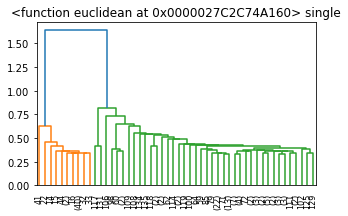

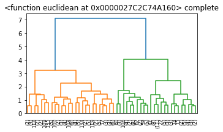

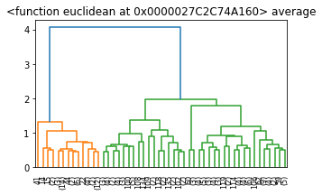

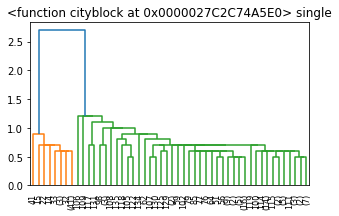

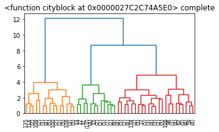

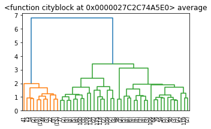

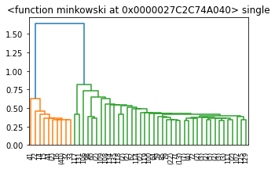

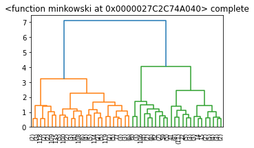

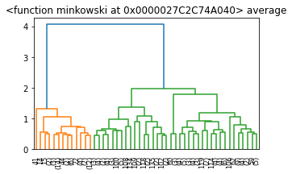

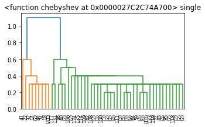

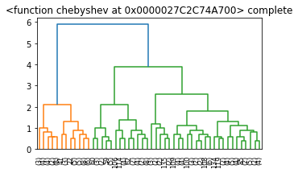

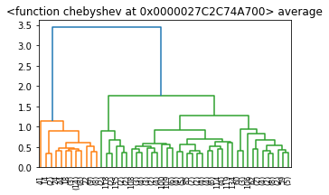

```python
metrics = [euclidean, cityblock, minkowski, chebyshev]
linkages = ['single', 'complete', 'average']
for metr in metrics:
    for link in linkages:
        m_cl = My_Clust(metric=metr, linkage=link, n_clusters=5)
        my_Z = m_cl.fit(x_cl)
        m_cl.get_labels()
        plt.figure(figsize=(5,3))
        _=h.dendrogram(my_Z, p=50, truncate_mode='lastp')
        plt.title(str(metr) + ' ' + link)
        plt.show()
```

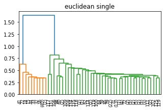

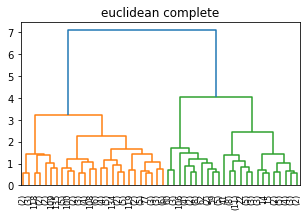

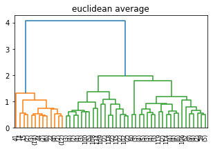

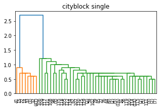

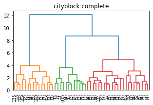

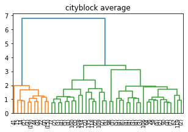

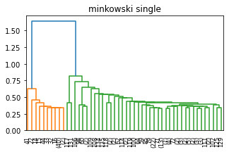

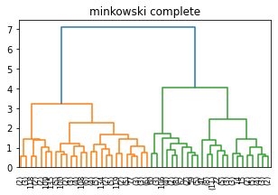

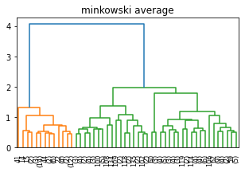

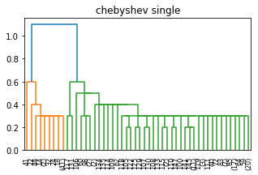

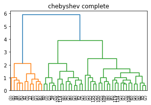

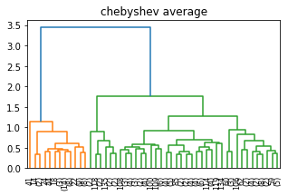

```python
metrics = ['euclidean', 'cityblock', 'minkowski', 'chebyshev']
for metr in metrics:
     for link in linkages:
        Z = h.linkage(X, method=link, metric=metr)
        labels_h = h.fcluster(Z, t=5, criterion='maxclust')
        plt.figure(figsize=(5,3))
        _=h.dendrogram(Z, p=50, truncate_mode='lastp')
        plt.title(metr +' ' + link)
        plt.show()
```

Если сравнить получившиеся графики, то они не отличаются друг от друга, получается что я провела верную кластеризацию, к сожалению медленную :(

# Часть 2

В данном задании вам предлагается проанализировать набор данных по различным городам США. Каждый город характеризуется следующими признаками:

```python
pd.set_option('display.max_colwidth', None)
```

```python
data_desc = pd.read_csv('Data_Description.txt', sep=':')
data_desc
```

|  | Attribute | Description |
| --- | --- | --- |
| 0 | Place | City, state (postal code) |
| 1 | Climate & Terrain | Very hot and very cold months, seasonal temperature variation, heating- and cooling-degree days, freezing days, zero-degree days, ninety-degree days. |
| 2 | Housing | Utility bills, property taxes, mortgage payments. |
| 3 | Health Care & Environment | Per capita physicians, teaching hospitals, medical schools, cardiac rehabilitation centers, comprehensive cancer treatment centers, hospices, insurance/hospitalization costs index, flouridation of dri… |
| 4 | Crime | Violent crime rate, property crime rate. |
| 5 | Transportation | Daily commute, public transportation, Interstate highways, air service, passenger rail service. |
| 6 | Education | Pupil/teacher ratio in the public K-12 system, effort index in K-12, accademic options in higher education. |
| 7 | The Arts | Museums, fine arts and public radio stations, public television stations, universities offering a degree or degrees in the arts, symphony orchestras, theatres, opera companies, dance companies, public… |
| 8 | Recreation | Good restaurants, public golf courses, certified lanes for tenpin bowling, movie theatres, zoos, aquariums, family theme parks, sanctioned automobile race tracks, pari-mutuel betting attractions, majo… |
| 9 | Economics | Average household income adjusted for taxes and living costs, income growth, job growth. |
| 10 | Longitude | Longitude |
| 11 | Latitude | Latitude |
| 12 | Population | Population |

### Notes:

- Для всех признаков, кроме трех, чем выше значение - тем лучше. Для признаков `Housing` и `Crime` - наоборот.
- Признак `Population`- статистический признак, не имеющий интерпретации как “лучше-хуже”.
- Признак `Place` - уникальный идентификатор объекта (города), он не должен использоваться при кластеризации.
- Также в данных присутствуют географические координаты городов - `Longitude` и `Latitude`. Их также не следует использовать при кластеризации данных.

```python
data = pd.read_csv('Data.txt', sep=' ')
data
```

|  | Place | Climate | HousingCost | HlthCare | Crime | Transp | Educ | Arts | Recreat | Econ | Long | Lat | Pop |
| --- | --- | --- | --- | --- | --- | --- | --- | --- | --- | --- | --- | --- | --- |
| 0 | Abilene,TX | 521 | 6200 | 237 | 923 | 4031 | 2757 | 996 | 1405 | 7633 | -99.6890 | 32.5590 | 110932 |
| 1 | Akron,OH | 575 | 8138 | 1656 | 886 | 4883 | 2438 | 5564 | 2632 | 4350 | -81.5180 | 41.0850 | 660328 |
| 2 | Albany,GA | 468 | 7339 | 618 | 970 | 2531 | 2560 | 237 | 859 | 5250 | -84.1580 | 31.5750 | 112402 |
| 3 | Albany-Schenectady-Troy,NY | 476 | 7908 | 1431 | 610 | 6883 | 3399 | 4655 | 1617 | 5864 | -73.7983 | 42.7327 | 835880 |
| 4 | Albuquerque,NM | 659 | 8393 | 1853 | 1483 | 6558 | 3026 | 4496 | 2612 | 5727 | -106.6500 | 35.0830 | 419700 |
| ... | ... | ... | ... | ... | ... | ... | ... | ... | ... | ... | ... | ... | ... |
| 324 | Worcester,MA | 562 | 8715 | 1805 | 680 | 3643 | 3299 | 1784 | 910 | 5040 | -71.7950 | 42.2720 | 402918 |
| 325 | Yakima,WA | 535 | 6440 | 317 | 1106 | 3731 | 2491 | 996 | 2140 | 4986 | -120.5130 | 46.5950 | 172508 |
| 326 | York,PA | 540 | 8371 | 713 | 440 | 2267 | 2903 | 1022 | 842 | 4946 | -76.7280 | 39.9600 | 381255 |
| 327 | Youngstown-Warren,OH | 570 | 7021 | 1097 | 938 | 3374 | 2920 | 2797 | 1327 | 3894 | -80.7290 | 41.1700 | 531350 |
| 328 | Yuba-City,CA | 608 | 7875 | 212 | 1179 | 2768 | 2387 | 122 | 918 | 4694 | -121.6220 | 39.1280 | 101979 |

329 rows × 13 columns

## Задания:

1. Выполните необходимую предобработку данных. Перед кластеризацией исключите из данных признаки `Place`, `Long` и `Lat`.
1. Выполните кластеризацию иерархическим методом.  
   Рассмотрите различные расстояния между объектами. Определите, какие следует использовать при кластеризации.  
   Выполните кластеризацию с различными расстояниями между кластерами. Сравните результаты, сделайте выводы.
1. Выполните кластеризацию методом Dbscan. Используйте расстояния между объектами, определенные в предыдущем пункте.  
   Реализуйте эвристику (см. лекции) для выбора параметров алгоритма. Подберите подходящие параметры алгоритма.
1. Выполните кластеризацию методом kmeans. Определите наилучшее (на ваш взгляд) число кластеров.
1. (Бонусное) Выполните кластеризацию другими методами. Например, [HDBSCAN](https://hdbscan.readthedocs.io/en/latest/) или алгоритмы, [реализованные](https://scikit-learn.org/stable/modules/clustering.html) в scikit-learn.
1. В результате выполнения предыдущих пунктов вы должны получить 4 или больше разбиений объектов (по одному на каждый метод). Сравните их между собой, сделайте выводы о сходствах и различиях.  
   Оцените результаты каждой кластеризации, используя метрики, рассмотренные на занятиях (Silhouette и прочие).
1. Выберите одно разбиение, наиболее подходящее на ваш взгляд. Предложите интерпретацию полученным кластерам или покажите, что этого сделать нельзя.
1. Оцените, как полученные кластеры распределены географически.  
   Оцените, как полученные кластеры распределены по штатам. Можно ли выделить какую-то зависимость (территориальную или для штатов)?  
   (Бонусное) [Провизуализируйте](https://python-visualization.github.io/folium/quickstart.html) распределение на карте США.

## Задание 1:

Выполните необходимую предобработку данных. Перед кластеризацией исключите из данных признаки Place, Long и Lat.

#### 1. Поиск пропущенных значений в данных.

```python
data.info()
```

```
<class 'pandas.core.frame.DataFrame'>
RangeIndex: 329 entries, 0 to 328
Data columns (total 13 columns):
 #   Column       Non-Null Count  Dtype
---  ------       --------------  -----
 0   Place        329 non-null    object
 1   Climate      329 non-null    int64
 2   HousingCost  329 non-null    int64
 3   HlthCare     329 non-null    int64
 4   Crime        329 non-null    int64
 5   Transp       329 non-null    int64
 6   Educ         329 non-null    int64
 7   Arts         329 non-null    int64
 8   Recreat      329 non-null    int64
 9   Econ         329 non-null    int64
 10  Long         329 non-null    float64
 11  Lat          329 non-null    float64
 12  Pop          329 non-null    int64
dtypes: float64(2), int64(10), object(1)
memory usage: 33.5+ KB
```

Каждый признак содержит 329 ненулевых записей (что соответствует числу объектов), значит явно пропущенных значений в данных нет.